# Project- Home Advantage

## Significance of home advantage in Top 5 European Football Leagues

The following notebook tries to do some basic exploratory data analysis of the top 5 European leagues. The dataset lists all the games in top five leagues (English Premier League, Serie A, Liga BBVA, Bundesliga and Ligue 1) from 1995 to 2020. The focus of this project will be on home advantage in European football.

The [dataset](https://www.kaggle.com/hikne707/big-five-european-soccer-leagues) was retreived from Kaggle and provided by the user '*Hicham IKNE*' and is named as `bigfive.csv`

```python
#importing necessary modules and libraries
import pandas as pd
import matplotlib.pyplot as plt
import seaborn as sb
import numpy as np
import scipy.stats as st
from statistics import mean

import warnings
warnings.filterwarnings('ignore')

#Setting up bold text
start = "\033[1m"
end = "\033[0;0m"
```

```python
#Load the data file into a pandas data frame
dfRaw= pd.read_csv('bigfive.csv')
#Provides a brief description of the dataframe
dfRaw.info()
dfRaw.head(5)
```

```
<class 'pandas.core.frame.DataFrame'>
RangeIndex: 44269 entries, 0 to 44268
Data columns (total 15 columns):
Round           44269 non-null int64
Date            44269 non-null object
Team 1          44269 non-null object
FT              44269 non-null object
HT              44269 non-null object
Team 2          44269 non-null object
Year            44269 non-null int64
Country         44269 non-null object
FT Team 1       44269 non-null int64
FT Team 2       44269 non-null int64
HT Team 1       44269 non-null int64
HT Team 2       44269 non-null int64
GGD             44269 non-null int64
Team 1 (pts)    44269 non-null int64
Team 2 (pts)    44269 non-null int64
dtypes: int64(9), object(6)
memory usage: 5.1+ MB
```

|  | Round | Date | Team 1 | FT | HT | Team 2 | Year | Country | FT Team 1 | FT Team 2 | HT Team 1 | HT Team 2 | GGD | Team 1 (pts) | Team 2 (pts) |
| --- | --- | --- | --- | --- | --- | --- | --- | --- | --- | --- | --- | --- | --- | --- | --- |
| 0 | 1 | (Sat) 19 Aug 1995 (W33) | Aston Villa FC | 3-1 | 3-0 | Manchester United FC | 1995 | ENG | 3 | 1 | 3 | 0 | 2 | 3 | 0 |
| 1 | 1 | (Sat) 19 Aug 1995 (W33) | Blackburn Rovers FC | 1-0 | 1-0 | Queens Park Rangers FC | 1995 | ENG | 1 | 0 | 1 | 0 | 1 | 3 | 0 |
| 2 | 1 | (Sat) 19 Aug 1995 (W33) | Chelsea FC | 0-0 | 0-0 | Everton FC | 1995 | ENG | 0 | 0 | 0 | 0 | 0 | 1 | 1 |
| 3 | 1 | (Sat) 19 Aug 1995 (W33) | Liverpool FC | 1-0 | 0-0 | Sheffield Wednesday FC | 1995 | ENG | 1 | 0 | 0 | 0 | 1 | 3 | 0 |
| 4 | 1 | (Sat) 19 Aug 1995 (W33) | Manchester City FC | 1-1 | 0-1 | Tottenham Hotspur FC | 1995 | ENG | 1 | 1 | 0 | 1 | 0 | 1 | 1 |

Due to all columns having equal number of non NULL values and there being a total of 44269 (total number of games), it is fair to assume that the data provided is valid. The 'FT' and 'HT' columns can be considered redundant as the same information is provided by other columns and hence can be removed.

```python
df=dfRaw[["Round","Date","Team 1","Team 2","Year","Country","FT Team 1","FT Team 2","HT Team 1","HT Team 2","Team 1 (pts)","Team 2 (pts)"]]
df
```

|  | Round | Date | Team 1 | Team 2 | Year | Country | FT Team 1 | FT Team 2 | HT Team 1 | HT Team 2 | Team 1 (pts) | Team 2 (pts) |
| --- | --- | --- | --- | --- | --- | --- | --- | --- | --- | --- | --- | --- |
| 0 | 1 | (Sat) 19 Aug 1995 (W33) | Aston Villa FC | Manchester United FC | 1995 | ENG | 3 | 1 | 3 | 0 | 3 | 0 |
| 1 | 1 | (Sat) 19 Aug 1995 (W33) | Blackburn Rovers FC | Queens Park Rangers FC | 1995 | ENG | 1 | 0 | 1 | 0 | 3 | 0 |
| 2 | 1 | (Sat) 19 Aug 1995 (W33) | Chelsea FC | Everton FC | 1995 | ENG | 0 | 0 | 0 | 0 | 1 | 1 |
| 3 | 1 | (Sat) 19 Aug 1995 (W33) | Liverpool FC | Sheffield Wednesday FC | 1995 | ENG | 1 | 0 | 0 | 0 | 3 | 0 |
| 4 | 1 | (Sat) 19 Aug 1995 (W33) | Manchester City FC | Tottenham Hotspur FC | 1995 | ENG | 1 | 1 | 0 | 1 | 1 | 1 |
| ... | ... | ... | ... | ... | ... | ... | ... | ... | ... | ... | ... | ... |
| 44264 | 26 | (Sun) 8 Mar 2020 (W10) | AC Milan | Genoa CFC | 2019 | IT | 1 | 2 | 0 | 2 | 0 | 3 |
| 44265 | 26 | (Sun) 8 Mar 2020 (W10) | UC Sampdoria | Hellas Verona FC | 2019 | IT | 2 | 1 | 0 | 1 | 3 | 0 |
| 44266 | 26 | (Sun) 8 Mar 2020 (W10) | Udinese Calcio | ACF Fiorentina | 2019 | IT | 0 | 0 | 0 | 0 | 1 | 1 |
| 44267 | 26 | (Sun) 8 Mar 2020 (W10) | Juventus | FC Internazionale Milano | 2019 | IT | 2 | 0 | 0 | 0 | 3 | 0 |
| 44268 | 26 | (Mon) 9 Mar 2020 (W11) | US Sassuolo Calcio | Brescia | 2019 | IT | 3 | 0 | 1 | 0 | 3 | 0 |

44269 rows × 12 columns

**NULL Hypothesis**

The rules of the league are such that each team plays every other team in the league twice over the course of a season: once at their home ground, and once at the opposition's home ground. The team playing at their stadium is called the home team and is denoted in the table as 'Team 1'. In the stadium, the home team has a larger section of fans allocated whereas the away team gets less stadium support [1]. Secondly, the ground conditions can be closely monitored by the team to suit their playing style. Moreover, the team plays at their home stadium multiple times a season resulting in familiar conditions. Furthermore, the away teams have to settle with travel and fewer locker room amenities just to name a few. All of these should perhaps result in the home team having an advantage.

*NULL Hypothesis* : In modern European football, home teams have had a significant and consistent home advantage over the away team.

To test the NULL hypothesis, two basic tests are designed focusing on the goals scored and win percentages.

**Test 1**

*Goals win you games* .Test 1 looks at the number of goals scored per game of football (denoted as goals p90). This would be one of the simplest ways to visualize whether a home team is consistently outperforming the away team.

```python
#Create a dataframe with only Year, FT Team 1 and FT Team 2 columns
dfSum = dfRaw[["Year","FT Team 1","FT Team 2"]]
#dfSum #Uncomment to view the dfSum table

#Creating a new column that is going to sum the home team and away team gaals then grouping them by year and summing them up
dfSum["Goals"]=dfSum["FT Team 1"]+dfSum["FT Team 2"]
dfCount = dfSum.groupby('Year')["Goals"].count()
dfSum= dfSum.groupby('Year').agg({'FT Team 1':["sum"],'FT Team 2':["sum"], 'Goals':["sum"]} )
dfSum = pd.merge(dfSum,dfCount,on ='Year')
dfSum.columns =['Home Team Tally','Away Team Tally', 'Cumulative', '# of Games']
season = np.linspace(1995,2019,25)
dfSum['Season']=season
df1= dfSum.drop(dfSum.index[24])
df2 = df1
#Getting the goals per game in a new dataframe
for index,row in df2.iterrows():
    df2['Home Goals p90'] = (df2['Home Team Tally']/df2['# of Games'])
    df2['Away Goals p90'] = (df2['Away Team Tally']/df2['# of Games'])
    df2['Goals p90'] = (df2['Cumulative']/df2['# of Games'])
df2
```

| Year | Home Team Tally | Away Team Tally | Cumulative | # of Games | Season | Home Goals p90 | Away Goals p90 | Goals p90 |
| --- | --- | --- | --- | --- | --- | --- | --- | --- |
| 1995 | 2827 | 1910 | 4737 | 1834 | 1995.0 | 1.541439 | 1.041439 | 2.582879 |
| 1996 | 2895 | 1949 | 4844 | 1834 | 1996.0 | 1.578517 | 1.062704 | 2.641221 |
| 1997 | 2642 | 1838 | 4480 | 1678 | 1997.0 | 1.574493 | 1.095352 | 2.669845 |
| 1998 | 2665 | 1731 | 4396 | 1678 | 1998.0 | 1.588200 | 1.031585 | 2.619785 |
| 1999 | 2710 | 1785 | 4495 | 1678 | 1999.0 | 1.615018 | 1.063766 | 2.678784 |
| 2000 | 2725 | 1871 | 4596 | 1678 | 2000.0 | 1.623957 | 1.115018 | 2.738975 |
| 2001 | 2599 | 1778 | 4377 | 1678 | 2001.0 | 1.548868 | 1.059595 | 2.608462 |
| 2002 | 2608 | 1855 | 4463 | 1752 | 2002.0 | 1.488584 | 1.058790 | 2.547374 |
| 2003 | 2689 | 1947 | 4636 | 1752 | 2003.0 | 1.534817 | 1.111301 | 2.646119 |
| 2004 | 2719 | 1912 | 4631 | 1826 | 2004.0 | 1.489047 | 1.047097 | 2.536145 |
| 2005 | 2618 | 1925 | 4543 | 1826 | 2005.0 | 1.433735 | 1.054217 | 2.487952 |
| 2006 | 2585 | 1949 | 4534 | 1826 | 2006.0 | 1.415663 | 1.067360 | 2.483023 |
| 2007 | 2760 | 1961 | 4721 | 1826 | 2007.0 | 1.511501 | 1.073932 | 2.585433 |
| 2008 | 2750 | 2033 | 4783 | 1826 | 2008.0 | 1.506024 | 1.113363 | 2.619387 |
| 2009 | 2830 | 2028 | 4858 | 1826 | 2009.0 | 1.549836 | 1.110624 | 2.660460 |
| 2010 | 2797 | 2047 | 4844 | 1826 | 2010.0 | 1.531763 | 1.121030 | 2.652793 |
| 2011 | 2879 | 2040 | 4919 | 1826 | 2011.0 | 1.576670 | 1.117196 | 2.693866 |
| 2012 | 2846 | 2176 | 5022 | 1826 | 2012.0 | 1.558598 | 1.191676 | 2.750274 |
| 2013 | 2875 | 2157 | 5032 | 1826 | 2013.0 | 1.574480 | 1.181271 | 2.755750 |
| 2014 | 2736 | 2062 | 4798 | 1826 | 2014.0 | 1.498357 | 1.129244 | 2.627601 |
| 2015 | 2766 | 2108 | 4874 | 1826 | 2015.0 | 1.514786 | 1.154436 | 2.669222 |
| 2016 | 2965 | 2211 | 5176 | 1826 | 2016.0 | 1.623768 | 1.210843 | 2.834611 |
| 2017 | 2794 | 2153 | 4947 | 1826 | 2017.0 | 1.530120 | 1.179080 | 2.709200 |
| 2018 | 2819 | 2200 | 5019 | 1826 | 2018.0 | 1.543812 | 1.204819 | 2.748631 |

The 2019-20 season was cutshort due to the covid-19 pandemic and hence the data from this season can be considered void. Secondly, there is a dip in the total number of games between 1997-2003. This change is considerable and the reason for it is unaccounted for as of yet. To take the lack of data into account, the goals p90 is going to be considered.

```
Mean number of home goals scored per 90 minutes of football: 1.5397
Mean number of away goals scored per 90 minutes of football: 1.1082
Mean number of total goals scored per 90 minutes of football: 2.6478
```

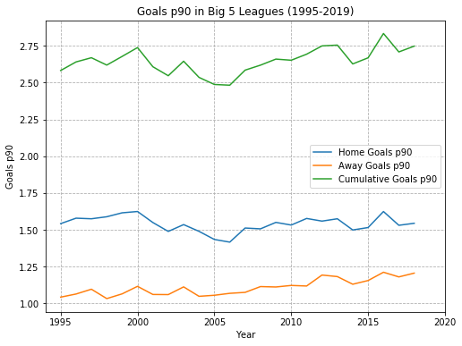

```python
plt.figure(figsize=(8,6))
homeGoals = df2['Home Goals p90']
plt.plot(homeGoals,label='Home Goals p90')
plt.legend()
plt.xlabel('Year')
plt.ylabel('Goals p90')

awayGoals = df2['Away Goals p90']
plt.plot(awayGoals, label='Away Goals p90')
plt.legend()

cumGoals = df2['Goals p90']
plt.plot(cumGoals, label = 'Cumulative Goals p90')
plt.grid(True,ls='--')
plt.title("Goals p90 in Big 5 Leagues (1995-2019)")
plt.plot(1.5397)
plt.xlim(1994,2020)
plt.legend();
print(f'Mean number of home goals scored per 90 minutes of football: {homeGoals.mean():.4f}')
print(f'Mean number of away goals scored per 90 minutes of football: {awayGoals.mean():.4f}')
print(f'Mean number of total goals scored per 90 minutes of football: {cumGoals.mean():.4f}')
```

Refering back to the table and the above plot, a somewhat noticeable trend is the increased away goals as season have progressed towards the present day with all seasons from 2008 having an away goal value above the mean, four of which are one positive standard deviation away from the mean. Whereas, only two seasons before 2008 had a score above the mean. This shows that although it can be said that there is a significant home advantage, it seems to be decreasing as football evolves.

To further test it, a second exploration will be useful. The second test will explore win percentages.

**Test 2**

To further explore the NULL hypothesis and compliment or contrast the trend above, this test will explore the win percentages over the years. Each win is awarded with 3 points to the winning side and 0 to the losing side. There are only three outcomes to a match: A win for a home team, a win for an away team, or a stalemate. These three values should add up to 1 or 100% to ensure that there have not been any errors in the data cleaning process.

To do the test, separate pandas series are formed for wins,draws and losses and they are then turned into percentages with respect to the total number of games in a season.

```python
#Selecting columns of Round, Year, Country, Team 1 pts and Team 2 pts as those are the only ones that are important for this
dfWins = dfRaw[["Round","Year","Country","Team 1 (pts)","Team 2 (pts)"]]
dfWins = dfWins[dfWins.Year!=2019]
dfC = dfWins.groupby('Year')["Round"].count()
dfWins = pd.merge(dfC,dfWins, on='Year')
del dfWins["Round_y"]
dfWins.rename(columns={'Year': 'Year', 'Round_x': 'Games','Country':'Country','Team 1 (pts)':'HomePoints','Team 2 (pts)':'Away Points'}, inplace=True)
dfGames=dfWins
```

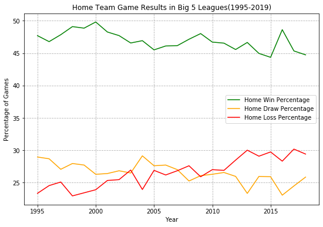

```python
dfWins=dfGames[dfGames.HomePoints!=0]
dfWins=dfWins[dfWins.HomePoints!=1]
winCount=dfWins.groupby('Year')["HomePoints"].count()
gameCount=df2['# of Games']
winPerc = (winCount/gameCount)*100

dfDraws=dfGames[dfGames.HomePoints==1]
drawCount=dfDraws.groupby('Year')['HomePoints'].count()
drawPerc = (drawCount/gameCount)*100

dfLoss=dfGames[dfGames.HomePoints==0]
lossCount = dfLoss.groupby('Year')['HomePoints'].count()
lossPerc = (lossCount/gameCount)*100

plt.figure(figsize=(9,6))
plt.plot(winPerc,label='Home Win Percentage',color= "Green")
plt.plot(drawPerc,label= 'Home Draw Percentage',color='Orange')
plt.plot(lossPerc,label='Home Loss Percentage',color='Red')
plt.grid(True,ls='--')
plt.title('Home Team Game Results in Big 5 Leagues(1995-2019)')
plt.xlabel('Year')
plt.ylabel('Percentage of Games')
plt.legend();
```

```python
res = {'Win Percentage':winPerc, 'Draw Percentage':drawPerc, 'Loss Percentage':lossPerc}
dfRes = pd.DataFrame(res)
dfRes
```

| Year | Win Percentage | Draw Percentage | Loss Percentage |
| --- | --- | --- | --- |
| 1995 | 47.709924 | 28.953108 | 23.336968 |
| 1996 | 46.782988 | 28.680480 | 24.536532 |
| 1997 | 47.854589 | 27.056019 | 25.089392 |
| 1998 | 49.106079 | 27.949940 | 22.943981 |
| 1999 | 48.867700 | 27.711561 | 23.420739 |
| 2000 | 49.821216 | 26.281287 | 23.897497 |
| 2001 | 48.271752 | 26.400477 | 25.327771 |
| 2002 | 47.716895 | 26.826484 | 25.456621 |
| 2003 | 46.575342 | 26.484018 | 26.940639 |
| 2004 | 46.933187 | 29.134721 | 23.932092 |
| 2005 | 45.509310 | 27.601314 | 26.889376 |
| 2006 | 46.111720 | 27.710843 | 26.177437 |
| 2007 | 46.166484 | 26.998905 | 26.834611 |
| 2008 | 47.152245 | 25.246440 | 27.601314 |
| 2009 | 48.028478 | 26.067908 | 25.903614 |
| 2010 | 46.714129 | 26.286966 | 26.998905 |
| 2011 | 46.549836 | 26.560789 | 26.889376 |
| 2012 | 45.564074 | 25.958379 | 28.477547 |
| 2013 | 46.659365 | 23.329682 | 30.010953 |
| 2014 | 44.961665 | 25.958379 | 29.079956 |
| 2015 | 44.359255 | 25.903614 | 29.737130 |
| 2016 | 48.630887 | 23.055860 | 28.313253 |
| 2017 | 45.345016 | 24.479737 | 30.175246 |
| 2018 | 44.742607 | 25.848850 | 29.408543 |

From the above, it's evident that there is a discernable home advantage with home wins ranging from 44%-50%. Home losses and draws make up the rest. But another trend is more visible in this than it was in the previous plot, i.e. away performances improving with seasons. To materialize the visual examination a comparison with means would be helpful.

```
Mean Home Wins:46.92
Mean Home Draws: 26.52
Mean Home Loss: 26.56
```

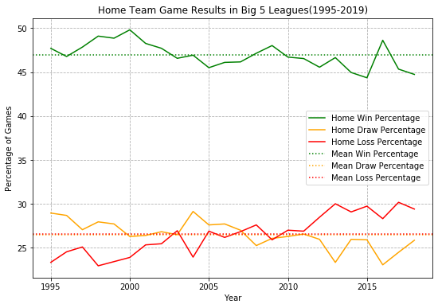

```python
#Comparing with the means

winMean = winPerc.mean()
drawMean = drawPerc.mean()
lossMean = lossPerc.mean()

plt.figure(figsize=(9,6))
plt.plot(winPerc,label='Home Win Percentage',color="Green")
plt.plot(drawPerc,label= 'Home Draw Percentage',color="Orange")
plt.plot(lossPerc,label='Home Loss Percentage',color="Red")
plt.grid(True,ls='--')
plt.title('Home Team Game Results in Big 5 Leagues(1995-2019)')
plt.xlabel('Year')
plt.ylabel('Percentage of Games')
plt.axhline(winMean, ls=':',label = "Mean Win Percentage",color = "Green")
plt.axhline(drawMean, ls=':',label = "Mean Draw Percentage",color="Orange")
plt.axhline(lossMean, ls=':',label = "Mean Loss Percentage",color='Red')
plt.legend();
print(f'Mean Home Wins:{winMean:.2f} \nMean Home Draws: {drawMean:.2f} \nMean Home Loss: {lossMean:.2f}')
```

It's evident that the NULL hypothesis of there being a home advantage is accepted. However, judging from the trends in both the home losses as well as the away goals the home advantage is less significant now than it was 20 years ago. The shifting point or the season is consistent in both the tests and it is 2008.

Sky Sports conducted a similar analysis in 2017 pertaining to the top four flights of the English football and commented that home advantage has seen a steady decline over the years and does not look like it's gonna pick back up [2].

The above graphs provide a generalized trend throughout Europe. Looking into league specific data could give more insights as to whether this trend is genuine and tangible in each individual league or is combining the leagues causing a false trend.

```python
'''
Step 1: Using df Dataset create 5 different country specific dataframes
Step 2: Group by Year and then create additional columns that give the p90 values
Step 3: Display the tables
'''

#England
dfEng = dfRaw[dfRaw.Country == 'ENG']
dfEng = dfEng[["Year","FT Team 1","FT Team 2","Team 1 (pts)","Team 2 (pts)"]]
dfEng["Goals"]=dfEng["FT Team 1"]+dfEng["FT Team 2"]
dfEngCount = dfEng.groupby('Year')['Goals'].count()
dfEng1 = dfEng.groupby('Year').agg({'FT Team 1':['sum'],'FT Team 2':['sum'],'Goals':['sum']})
dfEng1 = dfEng1.drop(dfEng1.index[24])
dfEng1 = pd.merge(dfEng1,dfEngCount,on = 'Year')
dfEng1.columns = ['Home Goals','Away Goals','Goals','Games']
for index,row in dfEng1.iterrows():
    dfEng1['Home Goals p90'] = dfEng1['Home Goals']/dfEng1['Games']
    dfEng1['Away Goals p90'] = dfEng1['Away Goals']/dfEng1['Games']
    dfEng1['Goals p90'] = dfEng1['Goals']/dfEng1['Games']
dfEng=dfEng1

#Italy
dfIta = df[df.Country == 'IT']
dfIta = dfIta[["Year","FT Team 1","FT Team 2","Team 1 (pts)","Team 2 (pts)"]]
dfIta["Goals"]=dfIta["FT Team 1"]+dfIta["FT Team 2"]
dfItaCount = dfIta.groupby('Year')['Goals'].count()
dfIta1 = dfIta.groupby('Year').agg({'FT Team 1':['sum'],'FT Team 2':['sum'],'Goals':['sum']})
dfIta1 = dfIta1.drop(dfIta1.index[24])
dfIta1 = pd.merge(dfIta1,dfItaCount,on = 'Year')
dfIta1.columns = ['Home Goals','Away Goals','Goals','Games']
for index,row in dfIta1.iterrows():
    dfIta1['Home Goals p90'] = dfIta1['Home Goals']/dfIta1['Games']
    dfIta1['Away Goals p90'] = dfIta1['Away Goals']/dfIta1['Games']
    dfIta1['Goals p90'] = dfIta1['Goals']/dfIta1['Games']
dfIta=dfIta1

#Germany
dfGer = df[df.Country == 'GER']
dfGer = dfGer[["Year","FT Team 1","FT Team 2","Team 1 (pts)","Team 2 (pts)"]]
dfGer["Goals"]=dfGer["FT Team 1"]+dfGer["FT Team 2"]
dfGerCount = dfGer.groupby('Year')['Goals'].count()
dfGer1 = dfGer.groupby('Year').agg({'FT Team 1':['sum'],'FT Team 2':['sum'],'Goals':['sum']})
dfGer1 = dfGer1.drop(dfGer1.index[24])
dfGer1 = pd.merge(dfGer1,dfGerCount,on = 'Year')
dfGer1.columns = ['Home Goals','Away Goals','Goals','Games']
for index,row in dfGer1.iterrows():
    dfGer1['Home Goals p90'] = dfGer1['Home Goals']/dfGer1['Games']
    dfGer1['Away Goals p90'] = dfGer1['Away Goals']/dfGer1['Games']
    dfGer1['Goals p90'] = dfGer1['Goals']/dfGer1['Games']
dfGer=dfGer1

#Spain
dfEsp = df[df.Country == 'ESP']
dfEsp = dfEsp[["Year","FT Team 1","FT Team 2","Team 1 (pts)","Team 2 (pts)"]]
dfEsp["Goals"]=dfEsp["FT Team 1"]+dfEsp["FT Team 2"]
dfEspCount = dfEsp.groupby('Year')['Goals'].count()
dfEsp1 = dfEsp.groupby('Year').agg({'FT Team 1':['sum'],'FT Team 2':['sum'],'Goals':['sum']})
dfEsp1 = dfEsp1.drop(dfEsp1.index[24])
dfEsp1 = pd.merge(dfEsp1,dfEspCount,on = 'Year')
dfEsp1.columns = ['Home Goals','Away Goals','Goals','Games']
for index,row in dfEsp1.iterrows():
    dfEsp1['Home Goals p90'] = dfEsp1['Home Goals']/dfEsp1['Games']
    dfEsp1['Away Goals p90'] = dfEsp1['Away Goals']/dfEsp1['Games']
    dfEsp1['Goals p90'] = dfEsp1['Goals']/dfEsp1['Games']
dfEsp=dfEsp1

#France
dfFra = df[df.Country == 'FR']
dfFra = dfFra[["Year","FT Team 1","FT Team 2","Team 1 (pts)","Team 2 (pts)"]]
dfFra["Goals"]=dfFra["FT Team 1"]+dfFra["FT Team 2"]
dfFraCount = dfFra.groupby('Year')['Goals'].count()
dfFra1 = dfFra.groupby('Year').agg({'FT Team 1':['sum'],'FT Team 2':['sum'],'Goals':['sum']})
dfFra1 = dfFra1.drop(dfFra1.index[24])
dfFra1 = pd.merge(dfFra1,dfFraCount,on = 'Year')
dfFra1.columns = ['Home Goals','Away Goals','Goals','Games']
for index,row in dfFra1.iterrows():
    dfFra1['Home Goals p90'] = dfFra1['Home Goals']/dfFra1['Games']
    dfFra1['Away Goals p90'] = dfFra1['Away Goals']/dfFra1['Games']
    dfFra1['Goals p90'] = dfFra1['Goals']/dfFra1['Games']
dfFra=dfFra1
```

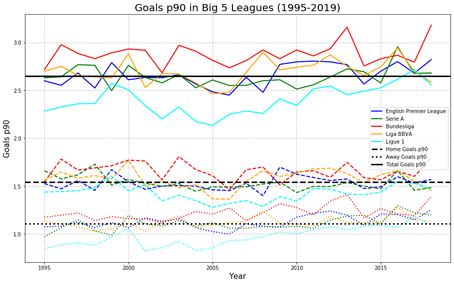

```python
plt.figure(figsize=(15,9))

homeGoalsEng = dfEng['Home Goals p90']
plt.plot(homeGoalsEng,lw=2,c='blue',ls='--')
awayGoalsEng = dfEng['Away Goals p90']
plt.plot(awayGoalsEng,lw=2,c='blue',ls=':')
cumGoalsEng = dfEng['Goals p90']
plt.plot(cumGoalsEng, label = 'English Premier League',lw=2,c='blue')

homeGoalsIta = dfIta['Home Goals p90']
plt.plot(homeGoalsIta,lw=2,c='green',ls='--')
awayGoalsIta = dfIta['Away Goals p90']
plt.plot(awayGoalsIta,lw=2,c='green',ls=':')
cumGoalsIta = dfIta['Goals p90']
plt.plot(cumGoalsIta, label = 'Serie A ',lw=2,c='green')

homeGoalsGer = dfGer['Home Goals p90']
plt.plot(homeGoalsGer,lw=2,c='red',ls='--')
awayGoalsGer = dfGer['Away Goals p90']
plt.plot(awayGoalsGer,lw=2,c='red',ls=':')
cumGoalsGer = dfGer['Goals p90']
plt.plot(cumGoalsGer, label = 'Bundesliga',lw=2,c='red')

homeGoalsEsp = dfEsp['Home Goals p90']
plt.plot(homeGoalsEsp,lw=2,c='orange',ls='--')
awayGoalsEsp = dfEsp['Away Goals p90']
plt.plot(awayGoalsEsp,lw=2,c='orange',ls=':')
cumGoalsEsp = dfEsp['Goals p90']
plt.plot(cumGoalsEsp, label = 'Liga BBVA',lw=2,c='orange')

homeGoalsFra = dfFra['Home Goals p90']
plt.plot(homeGoalsFra,lw=2,c='aqua',ls='--')
awayGoalsFra= dfFra['Away Goals p90']
plt.plot(awayGoalsFra,lw=2,c='aqua',ls=':')
cumGoalsFra = dfFra['Goals p90']
plt.plot(cumGoalsFra, label = 'Ligue 1',lw=2,c='aqua')

plt.axhline(homeGoals.mean(),color='black',lw=3,ls="--",label = 'Home Goals p90')
plt.axhline(awayGoals.mean(),color='black',lw=3,ls=":",label = 'Away Goals p90')
plt.axhline(cumGoals.mean(),color='black',lw=3,label='Total Goals p90')

plt.grid(True,ls='--')
plt.title("Goals p90 in Big 5 Leagues (1995-2019)",fontsize=20)
plt.xlabel('Year',fontsize=15)
plt.ylabel('Goals p90',fontsize=15)
plt.legend();
```

One of the reasons why Test 1 and 2 might have been flawed was that it was a much bigger picture data i.e. it took into account all games in European Top 5 leagues. This could lead to a single or even two leagues overcompensating and massively skewing the plots. The trend that's so far been discerned is that home advantage of teams is reducing enough for it to be noticeable. The question remained, 'What if it was just one league that was introducing that trend?' Looking at the graph above, we can say that certainly doesn't seem to be the case. Infact, all five leagues are following the previously observed trend. A closer inspection at the 'Away Goals p90 graph is warranted'.

*Reasons for not focusing on the Home Goals and Total Goals: The graph for Home goals doesn't seem to be showing any discernable pattern and seems to be oscillating in between a narrow range. The Total Goals p90 increases as the game progresses towards the modern era but this seems to be in proportion to the away goals increasing.*

*Side Note: If what you want is end to end action, then Bundesliga is your best bet and if you have trouble sleeping then perhaps give Ligue 1 a try.*

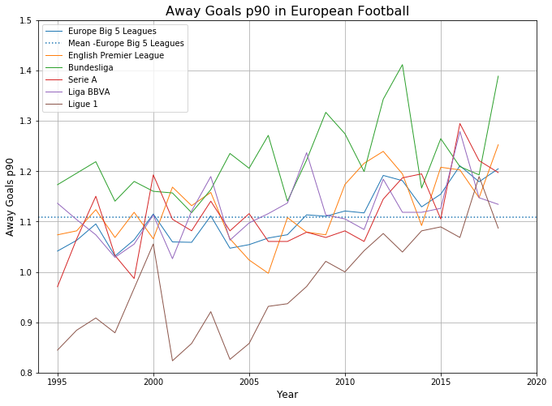

```python
plt.figure(figsize=(11,8))
plt.plot(awayGoals,lw=1,label='Europe Big 5 Leagues')
plt.axhline(awayGoals.mean(),ls=':',label='Mean -Europe Big 5 Leagues')
plt.plot(awayGoalsEng,lw=1,label='English Premier League')
plt.plot(awayGoalsGer,lw=1,label='Bundesliga')
plt.plot(awayGoalsIta,lw=1,label='Serie A')
plt.plot(awayGoalsEsp,lw=1,label='Liga BBVA')
plt.plot(awayGoalsFra,lw=1,label='Ligue 1')
plt.ylim(0.8,1.5)
plt.xlim(1994,2020)
plt.grid()
plt.title('Away Goals p90 in European Football',fontsize=16)
plt.xlabel('Year',fontsize=12)
plt.ylabel('Away Goals p90',fontsize=12)
plt.legend(loc=2);
```

```python
from scipy.stats import stats
listAwayGoals=[awayGoals,dfEng['Away Goals p90'],dfGer['Away Goals p90'],dfEsp['Away Goals p90'],dfIta['Away Goals p90'],dfFra['Away Goals p90']]
corrList=[]
pValue=[]
i=0
for x in listAwayGoals:
    corr,pVal = stats.pearsonr(np.linspace(1995,2018,24),x)
    corrList.append(corr)
    pValue.append(pVal)
corrList=[round(elem, 5) for elem in corrList ]
pValue = [round(elem,6) for elem in pValue]
```

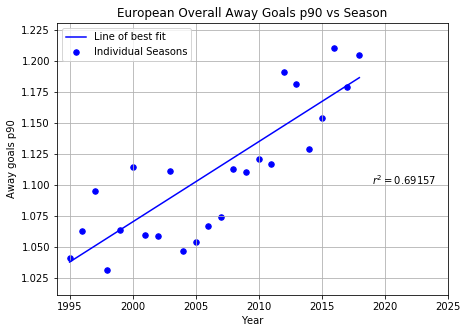

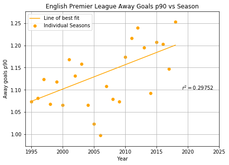

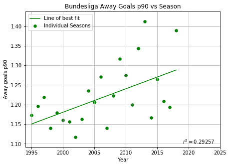

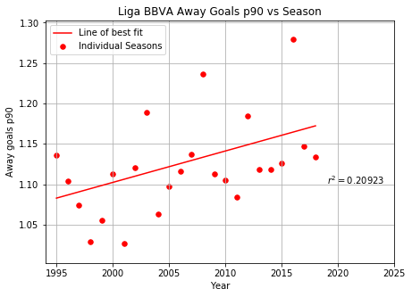

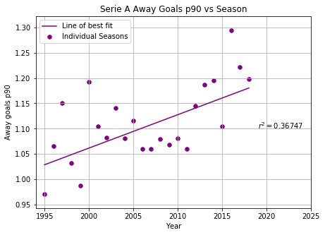

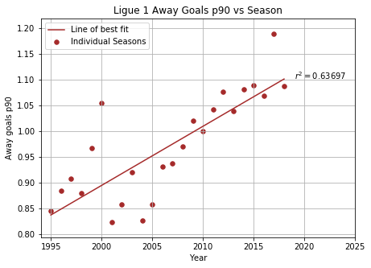

```python
ys=[awayGoals,awayGoalsEng,awayGoalsGer,awayGoalsEsp,awayGoalsIta, awayGoalsFra]
xs = np.linspace(1995,2018,24)
xs = np.array(xs,dtype = np.float64)
rSquared =[]
bestFit=[]
color = ['blue','orange','green','red','purple','brown']
labels = ['European Overall','English Premier League','Bundesliga','Liga BBVA','Serie A','Ligue 1']
i=0;
for element in ys:
    ys = np.array(element,dtype = np.float64)

    def bestFitSlope(a,b):
        m = (((mean(xs)*mean(ys)) - mean(xs*ys)) /((mean(xs)*mean(xs)) - mean(xs*xs)))

        b = mean(ys) - m*mean(xs)

        return m, b
    m,b=bestFitSlope(xs,ys)
    m=m.round(5)
    b=b.round(5)
    bestFitLine = str(m)+'x'+str(b)
    bestFit.append(bestFitLine)

    regLine=[]
    for x in xs:
        regLine.append((m*x)+b)

    def squaredError(ys,ysLine):
        return sum((ysLine-ys)*(ysLine-ys))

    def coeffR(ys,ysLine):
        yMean = [mean(ys) for y in ys]
        sqErrorReg = squaredError(ys,ysLine)
        sqErroryMean = squaredError(ys,yMean)
        return 1-(sqErrorReg/sqErroryMean)

    r = coeffR(ys,regLine).round(5)
    rSquared.append(r)

    plt.figure(figsize=(7,5))
    plt.scatter(xs,ys,s=30,label='Individual Seasons',color=color[i])
    plt.title(labels[i]+' Away Goals p90 vs Season')
    plt.xlabel('Year')
    plt.ylabel('Away goals p90')
    plt.xlim(1994,2025)
    plt.text(2019,1.1,'$r^2=$'+str(r))
    plt.plot(xs,regLine,color=color[i],label='Line of best fit')
    plt.grid(True)
    plt.legend(loc=2)
    i+=1
```

```python
league=['Overall(Europe)','English Premier League(England)','Bundesliga(Germany)','Liga BBVA(Spain)','Serie A(Italy)','Ligue 1 (France)']
corrTab={'League':league,'Coeff of Correlation ($r$)':corrList,'  p-Value  ':pValue,'Regression Best Fit Line':bestFit,'Coeff of Determination ($r^2$)':rSquared }
print(start + '                             Summary Table for Away Goals vs Season' + end)
dfcorrTab = pd.DataFrame(corrTab)
dfcorrTab
```

```
                             Summary Table for Away Goals vs Season
```

|  | League | Coeff of Correlation ($r$) | p-Value | Regression Best Fit Line | Coeff of Determination ($r^2$) |
| --- | --- | --- | --- | --- | --- |
| 0 | Overall(Europe) | 0.83532 | 0.000000 | 0.00647x-11.86968 | 0.69157 |
| 1 | English Premier League(England) | 0.56451 | 0.004057 | 0.00549x-9.87827 | 0.29752 |
| 2 | Bundesliga(Germany) | 0.54286 | 0.006124 | 0.00599x-10.79956 | 0.29257 |
| 3 | Liga BBVA(Spain) | 0.47076 | 0.020246 | 0.00389x-6.67773 | 0.20923 |
| 4 | Serie A(Italy) | 0.61350 | 0.001432 | 0.00659x-12.11827 | 0.36747 |
| 5 | Ligue 1 (France) | 0.79909 | 0.000003 | 0.01148x-22.06523 | 0.63697 |

The above regression fit and modelling does seem to suggest that there is an upward trend in all the leagues in Europe. The coefficient of determination however suggests that the respective linear fits aren't that great. However, it is enough proof along with the correlation coefficient that there certainly is a positive trend with the number of away goals as the years have progressed.

*Coefficient of Correlation*: Coefficient of correlation is used to determine the degree to which two variables movements are associated. The farther the value is from zero the more correlated the two axes are. A positive value results in positive correlation and a negative value negative correlation. The *r* column for the above table definitely shows a positive trend in all the leagues and in Europe overall. This can be inferred as the away teams scoring more goals as the game evolves towards modern era. The subsequent p-Values can provide a good indication as to how accurate the hypothesis testing is. The NULL hypothesis stated that the significance of the home advantage is constant. However, these p values, all of which are p<0.05 show enough significance to be able to reject the NULL hypothesis and say with 95% certainty that the significance of home advantage is decreasing.

*Coefficient of Determination* : The coefficient of determination is used for regression analysis and to test the goodness of the line of bet fit. Coefficient of determination indicates the extent to which the variance in y can be predicted by the variance in x. Just like *r*, a value close to 1 is desirable and suggests high predictability of y-axis based on the x-axis. All the leagues do share a value higher than zero, a majority ranging from 0.2-0.37. This means on average only 20 to 37% of the data fit the regression model well. That's not a very good fit and it suggests a somewhat weak correlation, but a correlation nonetheless. However, there is Ligue 1 which seems to be an outlier causing a significant impact in the Overall European fit as well. Perhaps a better regression algorithm would provide a more accurate understanding.

*Ligue 1 and its Impact on the Overall model* - Ligue 1 seems to be the outright outlier in this trend with a very positive coefficient of correlation and likewise with the coefficient of determination. As to why this may be the case? Perhaps it is due to heavy investments in the top couple of teams like PSG, AS Monaco and them being able to steamroll lower opposition. This perhaps has a knock-on affect on the Overall picture as well causing the correlation to be so high. However, the overall values are averages taken directly from the raw data so some of the irregularities in the french league could have perhaps been smoothed out by the other 4 leagues. This should be explored further.

One of the reasons that Ligue 1 has seen such a positive correlation could simply be due to the league in general preferring a more attacking football as the seasons have progressed. Hence it's important to separate away goals and away wins. These do not mean the same thing. High away goals can still result in lower away wins if the home team scores more goals in conjunction. So, to have more confidence to come to any conclusion, more focus needs to be placed on away win percentages too.

##### Correlation and Determination Test on Away Win Percentage

```python
dfRaw = dfRaw[df.Year!=2019]

#England
dfEngLoss = dfRaw[df.Country=='ENG']
eg = dfEngLoss.groupby('Year')['Round'].count()
dfEngLoss  = dfEngLoss[['Year','Team 2 (pts)']]
dfEngLoss.columns = ['Year','Away']
dfEngLoss = dfEngLoss[dfEngLoss.Away==3]
elc = dfEngLoss.groupby('Year')['Away'].count()
dfEngL = pd.merge(elc,eg,on='Year')
dfEngL['LossP']= 100*dfEngL['Away']/dfEngL['Round']

#Germany
dfGerLoss = dfRaw[df.Country == 'GER']
gg = dfGerLoss.groupby('Year')['Round'].count()
dfGerLoss  = dfGerLoss[['Year','Team 2 (pts)']]
dfGerLoss.columns = ['Year','Away']
dfGerLoss = dfGerLoss[dfGerLoss.Away==3]
glc = dfEngLoss.groupby('Year')['Away'].count()
dfGerL = pd.merge(glc,gg,on='Year')
dfGerL['LossP']= 100*dfGerL['Away']/dfGerL['Round']

#Spain
dfEspLoss = dfRaw[df.Country == 'ESP']
sg = dfEspLoss.groupby('Year')['Round'].count()
dfEspLoss  = dfEspLoss[['Year','Team 2 (pts)']]
dfEspLoss.columns = ['Year','Away']
dfEspLoss = dfEspLoss[dfEspLoss.Away==3]
slc = dfEspLoss.groupby('Year')['Away'].count()
dfEspL = pd.merge(slc,sg,on='Year')
dfEspL['LossP']= 100*dfEspL['Away']/dfEspL['Round']

#Italy
dfItaLoss = dfRaw[df.Country == 'IT']
ig = dfItaLoss.groupby('Year')['Round'].count()
dfItaLoss  = dfItaLoss[['Year','Team 2 (pts)']]
dfItaLoss.columns = ['Year','Away']
dfItaLoss = dfItaLoss[dfItaLoss.Away==3]
ilc = dfItaLoss.groupby('Year')['Away'].count()
dfItaL = pd.merge(ilc,ig,on='Year')
dfItaL['LossP']= 100*dfItaL['Away']/dfItaL['Round']

#France
dfFraLoss = dfRaw[df.Country == 'FR']
fg = dfFraLoss.groupby('Year')['Round'].count()
dfFraLoss  = dfFraLoss[['Year','Team 2 (pts)']]
dfFraLoss.columns = ['Year','Away']
dfFraLoss = dfFraLoss[dfFraLoss.Away==3]
flc = dfFraLoss.groupby('Year')['Away'].count()
dfFraL = pd.merge(flc,fg,on='Year')
dfFraL['LossP']= 100*dfFraL['Away']/dfFraL['Round']
```

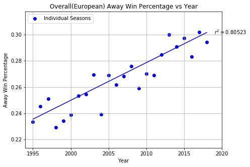

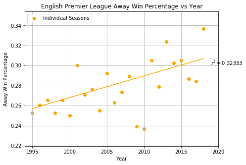

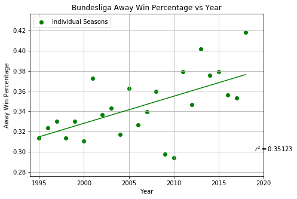

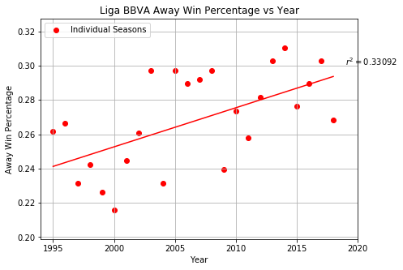

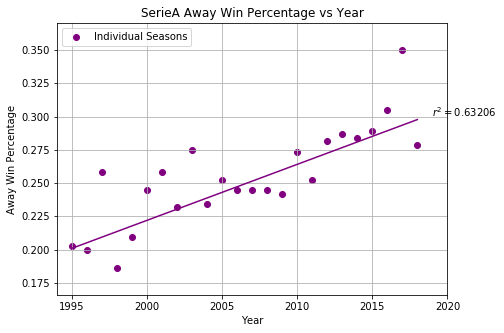

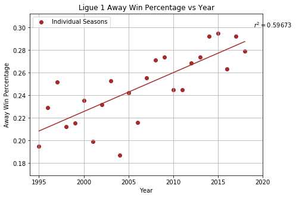

```python
dfs = [lossPerc, dfEngL['LossP'],dfGerL['LossP'],dfEspL['LossP'],dfItaL['LossP'],dfFraL['LossP']]
xs = np.array(np.linspace(1995,2018,24),dtype = np.float64)
rSquaredWins=[]
bestFitWins=[]
c=['blue','orange','green','red','purple','brown']
i=0
labels = ['Overall(European)','English Premier League','Bundesliga','Liga BBVA','SerieA','Ligue 1']
for element in dfs:
    ys = np.array(element/100,dtype = np.float64)

    def bestFitSlopeWins(c,d):
        m = (((mean(c)*mean(d))-mean(c*d))/((mean(c)*mean(c))-mean(c*c)))
        b = mean(d)-m*mean(c)
        return m,b

    m,b=bestFitSlopeWins(xs,ys)

    m=m.round(5)
    b = b.round(5)
    bestFitLine = str(m)+'x'+str(b)
    bestFitWins.append(bestFitLine)
    regLineWins=[]
    for x in xs:
        regLineWins.append((m*x)+b)

    def squaredError(ys,ysLine):
        return sum((ysLine-ys)*(ysLine-ys))

    def coeffRWins(ys,ysLine):
        yMean = [mean(ys) for y in ys]
        sqErrorReg = squaredError(ys,ysLine)
        sqErroryMean = squaredError(ys,yMean)
        return 1-(sqErrorReg/sqErroryMean)

    r = coeffRWins(ys,regLineWins).round(5)
    rSquaredWins.append(r)


    plt.figure(figsize=(7,5))
    plt.scatter(xs,ys,label='Individual Seasons',color=c[i])
    plt.title(labels[i] + ' Away Win Percentage vs Year')
    plt.plot(xs,regLineWins,color=c[i])
    plt.grid(True)
    plt.xlabel('Year')
    plt.xlim(1994,2020)
    plt.ylabel('Away Win Percentage')
    plt.text(2019,0.3,'$r^2=$'+str(r))
    plt.legend(loc=2)
    i+=1
```

```python
dfAwayWins = [lossPerc, dfEngL['LossP'],dfGerL['LossP'],dfEspL['LossP'],dfItaL['LossP'],dfFraL['LossP']]
i = 0
corrListWins = []
pValueWins = []
for x in dfAwayWins:
    corr,pVal = stats.pearsonr(np.linspace(1995,2018,24),x)
    corrListWins.append(corr)
    pValueWins.append(pVal)
corrListWins=[round(elem, 5) for elem in corrListWins ]
pValueWins = [round(elem,5) for elem in pValueWins]
```

```python
leagueWins=['Overall(Europe)','English Premier League(England)','Bundesliga(Germany)','Liga BBVA(Spain)','Serie A(Italy)','Ligue 1 (France)']
corrTabWins={'League':leagueWins,'Coeff of Correlation ($r$)':corrListWins,'  p-Value  ':pValueWins,'Regression Best Fit Line':bestFitWins,'Coeff of Determination ($r^2$)':rSquaredWins}
print(start + '                             Summary Table for Away Wins vs Season' + end)
dfcorrTabWins = pd.DataFrame(corrTabWins)
dfcorrTabWins
```

```
                             Summary Table for Away Wins vs Season
```

|  | League | Coeff of Correlation ($r$) | p-Value | Regression Best Fit Line | Coeff of Determination ($r^2$) |
| --- | --- | --- | --- | --- | --- |
| 0 | Overall(Europe) | 0.90756 | 0.00000 | 0.00287x-5.49011 | 0.80523 |
| 1 | English Premier League(England) | 0.59288 | 0.00226 | 0.00216x-4.05196 | 0.32333 |
| 2 | Bundesliga(Germany) | 0.59288 | 0.00226 | 0.00268x-5.03185 | 0.35123 |
| 3 | Liga BBVA(Spain) | 0.57814 | 0.00309 | 0.00228x-4.30735 | 0.33092 |
| 4 | Serie A(Italy) | 0.81343 | 0.00000 | 0.00421x-8.19807 | 0.63206 |
| 5 | Ligue 1 (France) | 0.77384 | 0.00001 | 0.00344x-6.6543 | 0.59673 |

Similar to the away goals, away wins per season also displays a positive correlation as the years have progressed. The correlation of coefficient on average is even slightly higher when compared to away goals and with a very high level of confidence in all of the leagues.

A final visual indicator of the trend is shown as below:

```
The Correlation Coefficient of the following scatter Matrix is: r = 0.8261
```

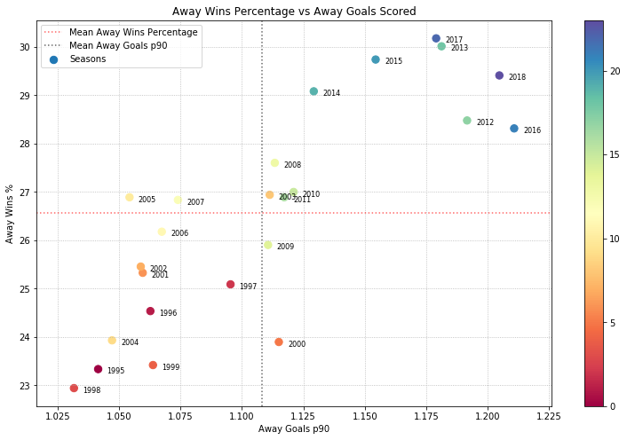

```python
from matplotlib import cm
from scipy import stats
cmap=cm.get_cmap('Spectral')
scatter = {'Away Goals p90': awayGoals, 'Away Wins %': lossPerc}
dfScatter= pd.DataFrame(scatter)
fig, ax = plt.subplots(figsize=(13,8))
dfScatter.plot('Away Goals p90', 'Away Wins %', kind='scatter', ax=ax,s=70, c=range(len(dfScatter)),colormap=cmap,label='Seasons')
plt.grid(True,ls=':')
for k,v in dfScatter.iterrows():
    ax.annotate(k,v,
                xytext=(10,-5),textcoords='offset points',family='sans-serif',fontsize=8,color='black')
plt.title('Away Wins Percentage vs Away Goals Scored')
plt.axhline(lossMean,ls=':',color='red',alpha =0.6,label="Mean Away Wins Percentage")
plt.axvline(1.1082,ls=':',color='black',alpha=0.6,label = "Mean Away Goals p90")
plt.legend(loc=2);

corr,pVal = stats.pearsonr(dfScatter['Away Goals p90'],dfScatter['Away Wins %'])
print(f'The Correlation Coefficient of the following scatter Matrix is: r = {corr:.4f}')
```

Like predicted, all but one season (2009) from 2008 onwards have seen a higher win percentage and higher number of goal scored per game away from home.

#### Conclusion

To answer that, it is imperative to look at holistic changes that are taking place in modern football. There are multiple facets that affect home advantage, here's a few of the plausible factors.

A research paper titled "Home advantage in sport: An overview of the studies on the advantage of playing at home" outlines the reasons as to why home teams have an advantage. The investigation found crowd size and home crowds to be the most dominant factor resulting in teams having a home advantage. According to the investigation, the crowd affects the outcome of the game in two distinct ways:

i. the crowd is able to raise the performance of the home competitors relative to the away competitors; or

ii. the crowd is able to influence the officials to subconsciously favour the home team [3]

Perhaps then one line of reasoning for changes is evolution of the crowd dynamics. According to a BBC survey in 2017, 55% of the fans under the age of 24 that were polled said that they had stopped going to games entirely. This poll was taken in UK where an average premier league game can cost upwards of 80 pounds. Similar levels of price discrimination is visible in Italian league, Spanish league and French league [4] where games can cost as much as 150 Euros. The only league where price discrimination is being actively addressed is the Bundesliga but many ticket scalpers take advantage of the low pricing to hoarde tickets only to sell for a profit [4].

The commercialization of European football leagues has created an entirely new tourism industry of Football Tourism. In the 2016-2017 season, English premier league saw 686,000 people coming into the country purely to watch high profile football games[5]. All of this has led to a mainstream narrative of an atmosphere of 'apathy'. The 'apathetic' nature of the crowds got comments from players and managers who suggested that the lethargic crowd was having a negative impact on the players [6]. The article was back in 2013 and the stadium atmosphere hasn't improved on that front since. Refering back to point (i), it is entirely plausible that crowds in European football haven't been the '12th man' in the recent years. Is stadium atmosphere the sole cause for this trend? Definitely not, but it could be seen as a contributing factor.

The second reason why home crowds are influential pertain to the officials. All it takes is one or two wrong decisions to shift the momentum of the game. A loud and brash crowd can influence the official to make biased decisions. This is perhaps supported by an experiment conducted on 40 referees who were made to watch Liverpool vs Leicester game from 1998-99 season. Half the referees were made to watch the game with the crowd sound and the other half without the sound. The researchers found that the referees who heard the sound of the crowd were less likely to call fouls against the home team than the ones who saw the game in silence. The preference for the home team coincided with the actual referee decisions [7]. However, with technology assistance like Goal line Technology and Video Assistant Referee being a regular part of the league systems since 2013 and 2017 respectively, match officials are less likely to make a human error affected by adverse crowd reactions.

Sure, the crowd may play an important role but that seems a rather intangible reason and can't be the only one. But there's multiple reasoning as suggested by this flowchart from a 2017 research paper [8].

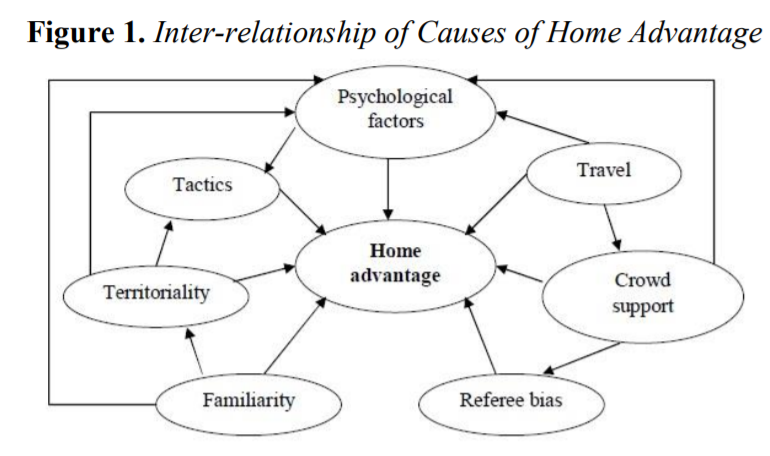

In recent decades, football has undergone huge changes in tactical, pyhiscal or technical aspects. The availabity of data and analysis tools has brought about a greater balance between the teams and can oppose greater resistance to the home advantage. The reduction of home advantage can also be attributed to more careful observation and detailed understanding of the opposition. This surely leads to better preparation and flexible adaptation such as more adept and personalized tactics when visiting different teams [8].

Research has also shown that home teams often have a sense of territoriality leading to an increase in testosterone levels compared to away teams [9]. As this paper states, that is consistent with the belief that isolated teams in culturally distinct communities have a high sense of territorial response. This, as suggested, can also contribute towards a home advantage. The current scenario of multicultural teams with players from all over the world may also contribute to the trend of decreasing home advantage.

**References:**

1. https://www.sportseconomics.org/sports-economics/away-fan-ticket-allocation-in-the-premier-league
2. https://www.skysports.com/football/news/11096/10955089/sky-sports-bust-common-football-myths-home-advantage
3. https://www.researchgate.net/publication/12734772_Home_advantage_in_sport_an_overview_of_studies_on_the_advantage_of_playing_at_home
4. https://www.bbc.com/sport/football/41901398
5. https://www.bbc.com/sport/football/49920019
6. https://www.theguardian.com/football/2013/nov/16/premier-league-fans-atmosphere-concern
7. https://www.theguardian.com/sport/2008/feb/03/features.sportmonthly16
8. https://www.athensjournals.gr/sports/2017-4-1-4-Leite.pdf
9. https://www.tandfonline.com/doi/full/10.1080/17461390903009133?src=recsys